# Homework 5

The only “close call” variable is `frost`, but the adjusted r-squared value decreased when you take `frost` out, so I chose to keep it in the model.

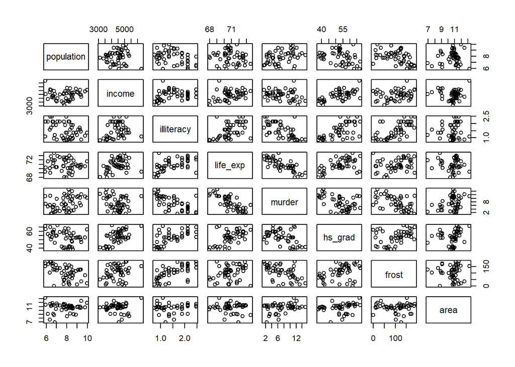

```r
pairs(state_data)
```

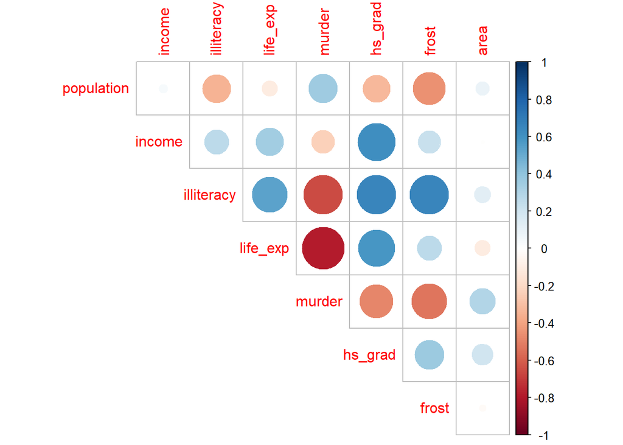

```r
corrplot(cor(state_data), type = "upper", diag = FALSE)
```

There is a strong relationship between `illiteracy` and `hs_grad`. Our subset only contains `hs_grad` and not `illiteracy`.

```r
subsets = regsubsets(life_exp ~., data = state_data)
subset_res = summary(subsets)

subset_res
```

```
## Subset selection object
## Call: regsubsets.formula(life_exp ~ ., data = state_data)
## 7 Variables  (and intercept)
##            Forced in Forced out
## population     FALSE      FALSE
## income         FALSE      FALSE
## illiteracy     FALSE      FALSE
## murder         FALSE      FALSE
## hs_grad        FALSE      FALSE
## frost          FALSE      FALSE
## area           FALSE      FALSE
## 1 subsets of each size up to 7
## Selection Algorithm: exhaustive
##          population income illiteracy murder hs_grad frost area
## 1  ( 1 ) " "        " "    " "        "*"    " "     " "   " "
## 2  ( 1 ) " "        " "    " "        "*"    "*"     " "   " "
## 3  ( 1 ) "*"        " "    " "        "*"    "*"     " "   " "
## 4  ( 1 ) "*"        " "    " "        "*"    "*"     "*"   " "
## 5  ( 1 ) "*"        " "    " "        "*"    "*"     "*"   "*"
## 6  ( 1 ) "*"        " "    "*"        "*"    "*"     "*"   "*"
## 7  ( 1 ) "*"        "*"    "*"        "*"    "*"     "*"   "*"
```

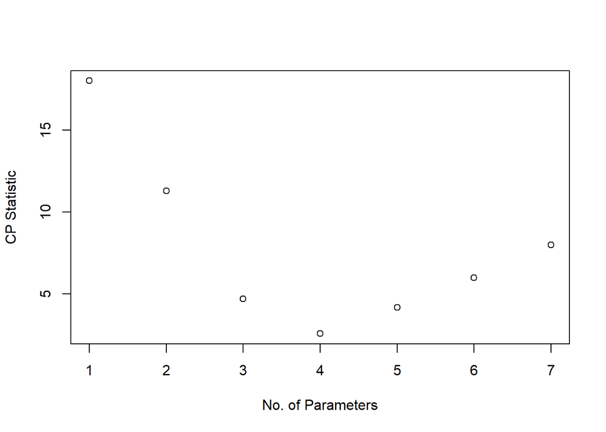

```r
plot(subset_res$cp, xlab = "No. of Parameters", ylab = "CP Statistic")
```

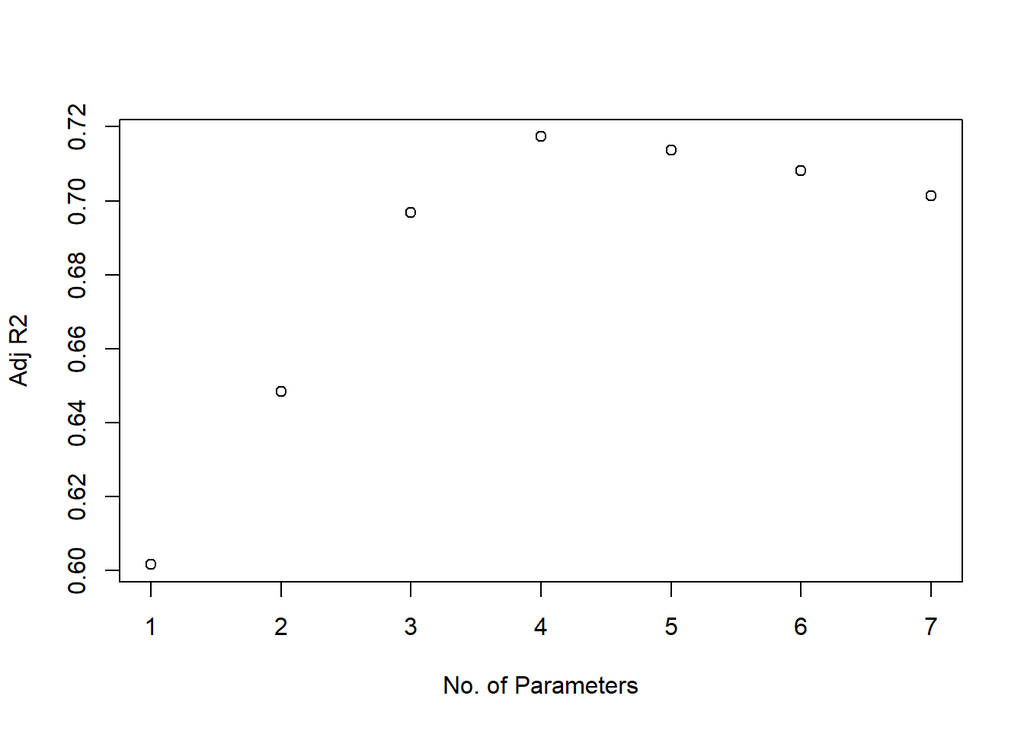

```r
plot(subset_res$adjr2, xlab = "No. of Parameters", ylab = "Adj R2")
```

From the regular subsetting, we can see that 4 parameters is the best model, which is what we got from forward, backward, and a combination of both in subsetting for a model.

```r
data <- state_data %>% select(-life_exp)
set.seed(5)
lambda_seq <- 10^seq(-3,0, by = 0.1)
cv_object <- cv.glmnet(as.matrix(data[1:7]), state_data$life_exp, lambda = lambda_seq, nfolds = 5)

cv_object
```

```
##
## Call:  cv.glmnet(x = as.matrix(data[1:7]), y = state_data$life_exp,      lambda = lambda_seq, nfolds = 5)
##
## Measure: Mean-Squared Error
##
##      Lambda Index Measure     SE Nonzero
## min 0.05012    14  0.6724 0.1240       4
## 1se 0.25119     7  0.7943 0.1719       2
```

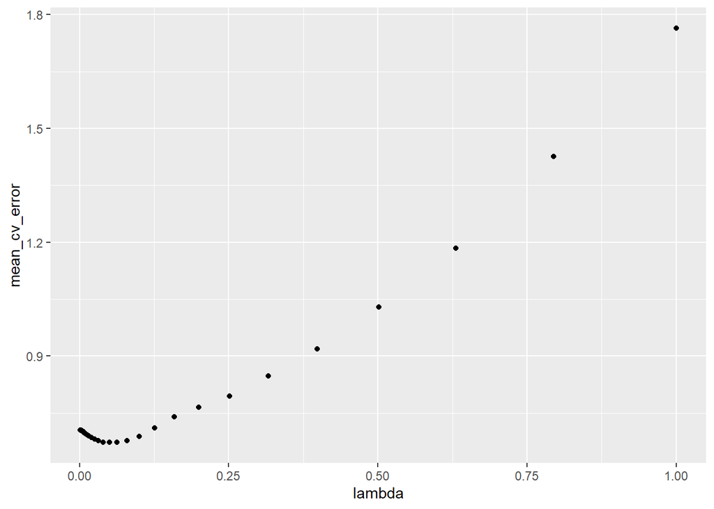

```r
tibble(lambda = cv_object$lambda,
       mean_cv_error = cv_object$cvm) %>%
  ggplot(aes(x = lambda, y = mean_cv_error)) + geom_point()
```

```r
cv_object$lambda.min
```

```
## [1] 0.05011872
```

```r
fit_bestcv <- glmnet(as.matrix(data[1:7]), state_data$life_exp, lambda = cv_object$lambda.min)
coef(fit_bestcv)
```

```
## 8 x 1 sparse Matrix of class "dgCMatrix"
##                      s0
## (Intercept) 69.17386637
## population   0.18944379
## income       .
## illiteracy   .
## murder      -0.26418480
## hs_grad      0.04729095
## frost       -0.00332490
## area         .
```

The best lambda for our model is 0.0501187.

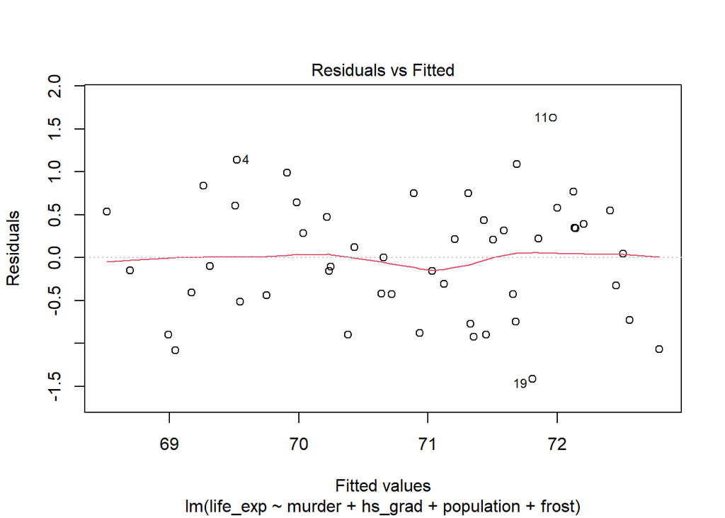

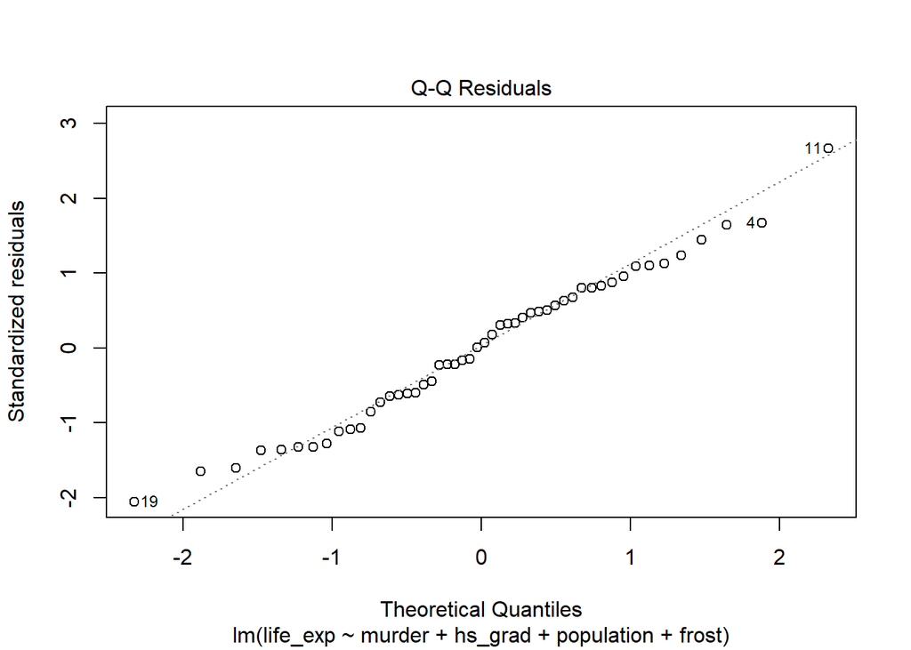

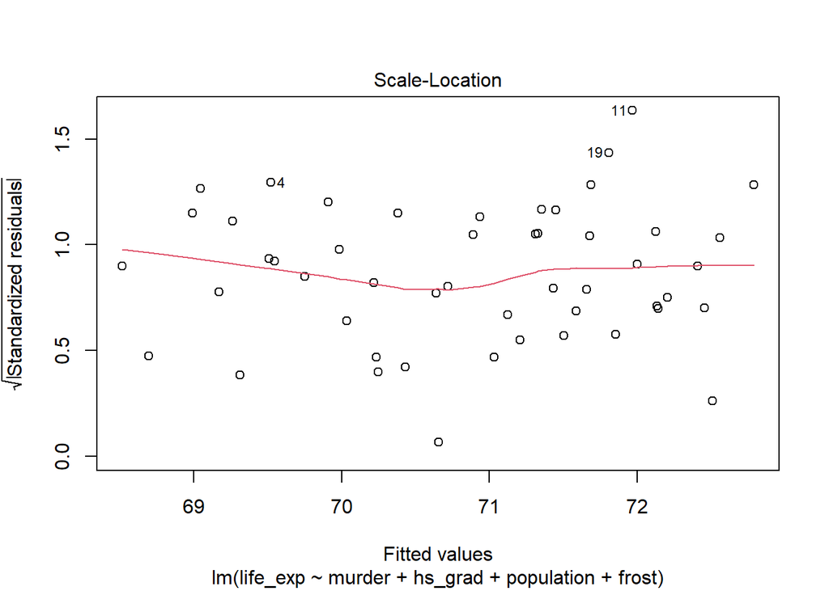

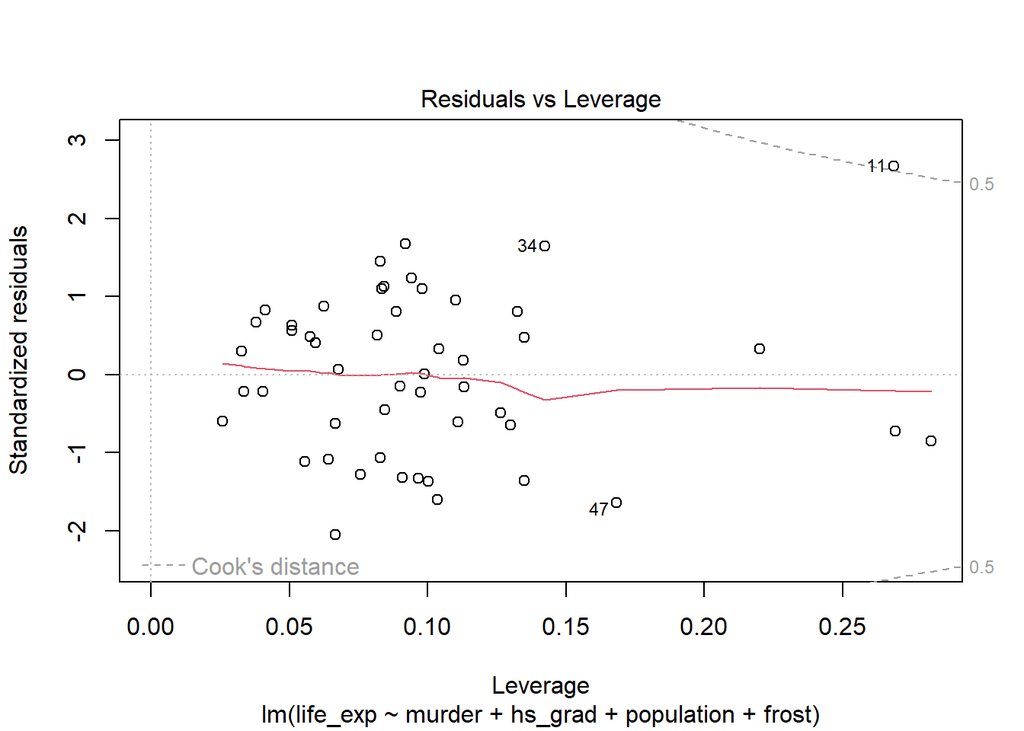

```r
plot(forward_model)
```

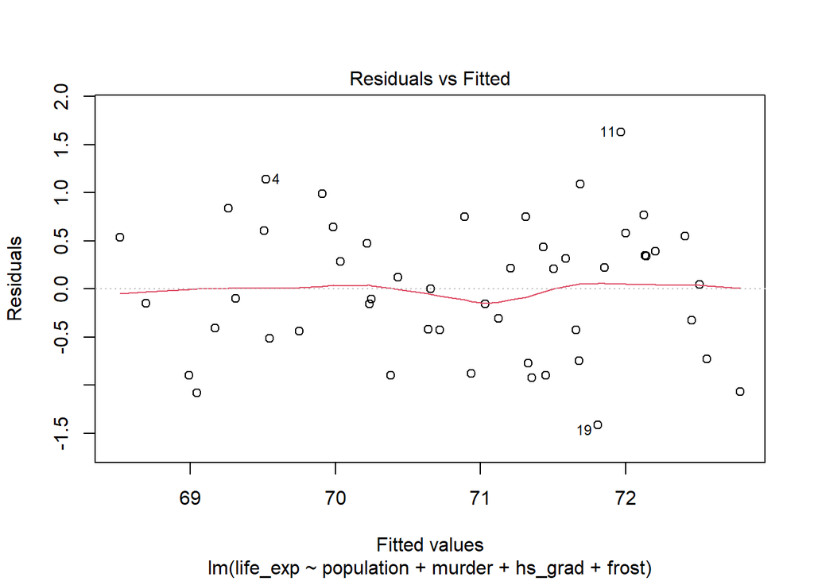

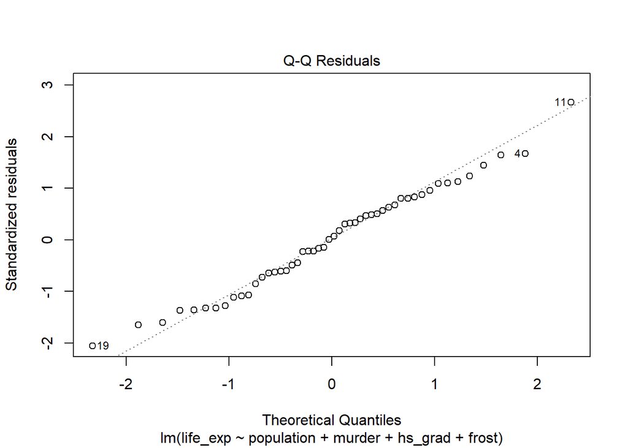

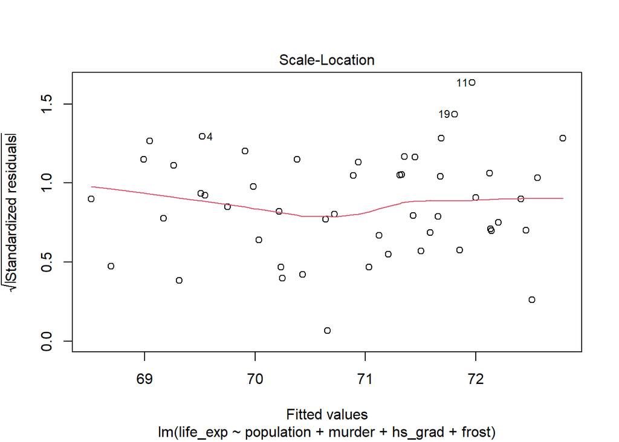

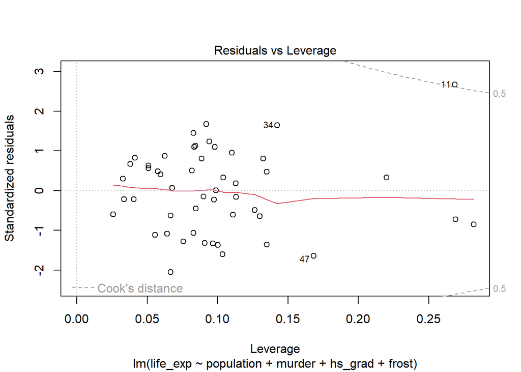

```r
plot(backward_model)
```